# Using technology to advance the the science: Digitizing research results to produce crop disease risk prediction tools

Mladen Cucak

Maynooth University Department of Geography, Maynooth University, Co. Kildare, Ireland; Teagasc Crops Research Centre, Oak Park, Carlow, Ireland

Rafael De Andrade Moral

Maynooth University Department of Mathematics and Statistics, Maynooth University, Co. Kildare, Ireland

Neil McRoberts

Quantitative Biology and Epidemiology (QBE) lab, Plant Pathology Department at UC Davis

# Background

The epidemics development of potato late blight, a most important potato crop disease caused by oomycete *Phytopthora infestans*, depends on availability and the race of pathogen and host and most importantly - suitability of the environment. Potato varieties grown are mostly susceptible to potato late blight due to tradition and market demandd. The pathogen is becoming more agressive due to increased diversification of its population since the 1970’s. Because of this, the use of pesticides is becoming increasingly prophylactic and and spray intervals are decreasing to as low as 3-4 days, leading to over 20 applications for a season in some places. Reliable tools build on scientific knowledge of the epidemiology of the disease are necessary now more than ever. The weather network and weather forecasting models are improving over time and today we are far away from where we were 10,20 years ago. Increasing availability of computing power allows researchers all over the world to develop plant disease prediction models, test, share and improve them.  
Unfortunately, this is not the current situation. A challenging need for and interdisciplinary approach is often a limiting factor for success of projects aiming to develop useful tools. There is a number of factors limiting the value of the models. The disease prediction models are often parochial in nature, limited to the environments where they were developed. Issues: User friendliness of the systems.

## Potential solutions

Reproducibility, common tools, open approach.  
We are proposing a method to partially overcome the above-mentioned issue of interdiscipinarity. R is an open source statistical programing language and one of most used data science tools.

# A case study

The methods in the study we have analysed here is easily replicated to a number of plant - pathogen systems. Duthie and Magarey have proposed simple infection models, but a great obstacle is usually the mathematical understanding and programatic implementation of the study analysis part. The Weibull function might be an appropriate model for the response to leaf wetness duration for two reasons. First, it has a suitable sigmoid cumulative distribution and second it has a location (or shift) parameter that can be interpreted in biological terms as a minimum requirement for suitable conditions before a process will occur. The Weibull function has many different parameterizations but one that is relevant for this problem is:
$$f(d) =\frac{\beta}{\eta} \left(\frac{t-\gamma}{\eta}\right)^{\beta-1} e^{\left(\frac{t-\gamma}{\eta}\right)^{\beta}}$$

Where $f(d)$ is the wetness-duration-dependent infection function, $\beta$ is the Weibull rate parameter, $\eta$ is the scale parameter (setting the characteristic duration over which events are completed), and $\gamma$ is the location parameter.

We choose a value (for function) for $\gamma$ that replicates what is know about the biology of the process. This leaves the issue of the remaining parameters $\beta$ and $\eta$. In essence, we construct functions for the response of these parameters to temperature and inoculum density, either from first principles, from data fitting, or a hybrid process. Then we plug the derived functions into the formula for the Weibull function, which becomes a translation device for turning input data for temperature, inoculum level and wetness duration into values for infection intensity.

Writing generic functional forms for the functions for $\beta$ and $\eta$ as $\beta\equiv h(T,I)$ and $\eta\equiv l(T,I)$, where $T$ and $I$ are temperature and inoculum level, respectively, we obtain:
$$f(d) =\frac{h(T,I)}{l(T,I)} \left(\frac{t-\gamma}{l(T,I)}\right)^{h(T,I)-1} e^{\left(\frac{t-\gamma}{l(T,I)}\right)^{h(T,I)}}$$

# The use of the available knowledge

Rotem(1971) investigated the levels of infection caused by 120 different level combinaitions of the environmental variables in a factorial experiment. The original paper is freely available from [Phytopathology](https://www.apsnet.org/publications/phytopathology/backissues/Documents/1971Articles/Phyto61n03_275.pdf)

# The implementation

## Packages

```r
list.of.packages <-
  c(
    "readxl",
    "here", #package that helps paths in different platforms
    "stringr", #string manipulations
    "reshape2", #Reshaping the data to long format, needed for plotting and model fitting
    "egg", #Plotting aids: interesting themes and putting together a number of plots
    "RColorBrewer", #Color palette
    "mgsub",
    "splines"

  )

new.packages <-
  list.of.packages[!(list.of.packages %in% installed.packages()[, "Package"])]

#Download packages that are not already present in the library
if (length(new.packages))
  install.packages(new.packages)

packages_load <-
  lapply(list.of.packages, require, character.only = TRUE)

#Print warning if there is a problem with installing/loading some of packages
if (any(as.numeric(packages_load) == 0)) {
  warning(paste("Package/s", paste(list.of.packages[packages_load != TRUE]), "not loaded!"))
} else {
  print("All packages were successfully loaded.")
}
```

```
## [1] "All packages were successfully loaded."
```

# Data

!!!!Check stadnard errors for various infection levels The data is imported and converted to long format.

```r
dis_df <- read_excel(here::here("cucak", "1", "dat", "P_inf_infection_Rotem.xlsx"))
dis_df <-
  reshape2::melt(dis_df, id.var = 1:2, variable.name = "temp", value.name = "dis_inc",factorsAsStrings = F)
dis_df$temp <- as.numeric(as.character.factor(dis_df$temp))

# dis_df$inoculum_dose <- factor(dis_df$inoculum_dose, ordered = T)
head(dis_df)
```

|  | inoculum_dose | wet_dur | temp | dis_inc |
| --- | --- | --- | --- | --- |
| 1 | 15 | 3 | 5 | 0 |
| 2 | 45 | 3 | 5 | 0 |
| 3 | 135 | 3 | 5 | 0 |
| 4 | 400 | 3 | 5 | 0 |
| 5 | 1200 | 3 | 5 | 0 |
| 6 | 15 | 6 | 5 | 0 |

## Initial exploration

Figure 2. depicting the results of the study is reproduced.

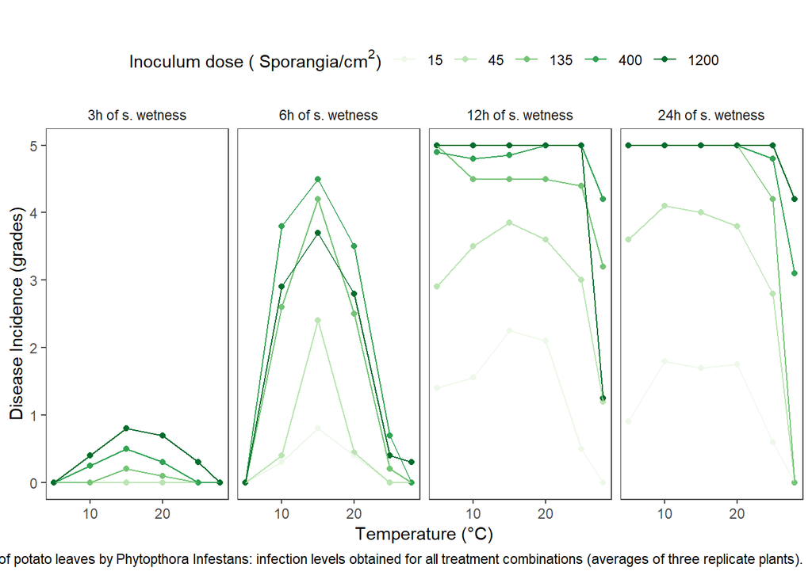

```r
dis_df$wet_dur_lab <- factor(dis_df$wet_dur)
levels(dis_df$wet_dur_lab) <- paste0(levels(dis_df$wet_dur_lab), "h of s. wetness")


ggplot(dis_df,aes(x= temp, y = dis_inc, group = factor(inoculum_dose), colour = factor(inoculum_dose)))+
geom_point()+
geom_line()+
facet_wrap(wet_dur_lab~., ncol = 4)+
 scale_color_brewer(palette="GrandBudapest")+
labs(
title = "",
x = "Temperature (°C)",
y = "Disease Incidence (grades)",
color = expression(paste("Inoculum dose ( Sporangia", "/",cm^2,")", sep="")),
caption = expression(paste(
"\nFigure 1. The effect of temperature (T, in °C), inoculum dose (Sporangia, in cm) and duration of wet period (W, in hr) on infection of potato leaves by ", "Phytopthora Infestans: infection levels obtained for all treatment combinations (averages of three replicate plants)."
)))+
theme_article()+
theme(legend.position = "top")
```

```r
dis_df$wet_dur_lab <- NULL
```

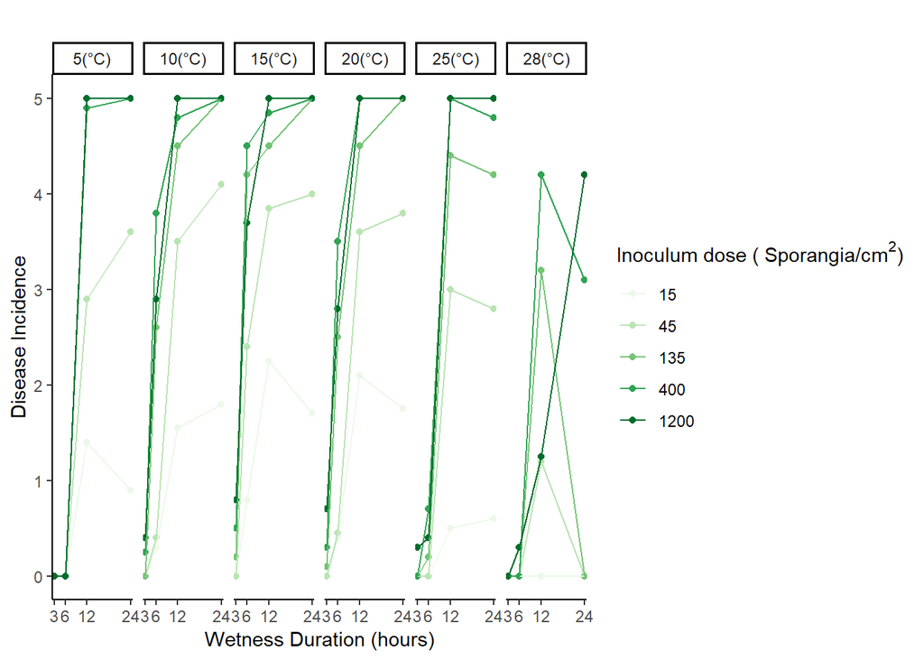

```r
dis_df$temp_lab <- factor(dis_df$temp)
levels(dis_df$temp_lab) <- paste0(levels(dis_df$temp_lab), "(°C)")


ggplot(dis_df,aes(x= wet_dur, y = dis_inc, group = factor(inoculum_dose), colour = factor(inoculum_dose)))+
  geom_point()+
  geom_line()+
  facet_wrap(temp_lab~., ncol = 6)+
  scale_color_brewer(palette="GrandBudapest")+
  scale_x_discrete(limits= unique(dis_df$wet_dur), labels = as.character(unique(dis_df$wet_dur)))+
  xlab("Wetness Duration (hours)")+
  ylab("Disease Incidence")+
  labs(
  title = "",
  color = expression(paste("Inoculum dose ( Sporangia", "/",cm^2,")", sep="")))+
  theme(legend.position = "top")+
  theme_classic()
```

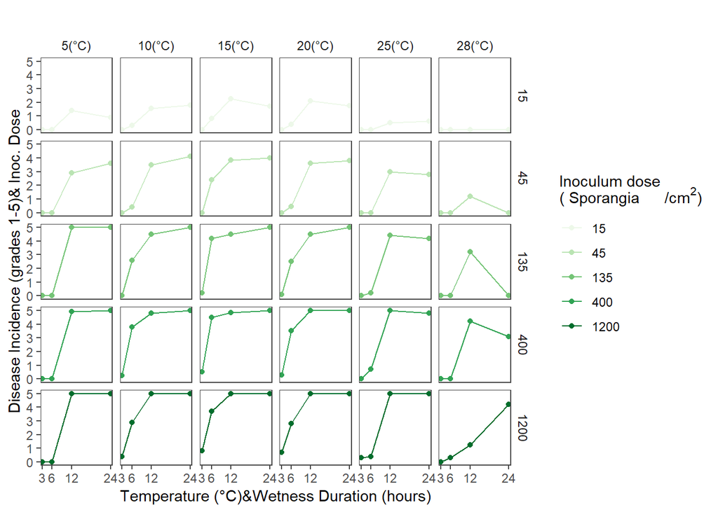

```r
ggplot(dis_df,aes(x= wet_dur, y = dis_inc, group = factor(inoculum_dose), colour = factor(inoculum_dose)))+
  geom_point()+
  geom_line()+
  facet_grid(inoculum_dose~ temp_lab)+
  scale_color_brewer(palette="GrandBudapest")+
  scale_x_discrete(limits= unique(dis_df$wet_dur), labels = as.character(unique(dis_df$wet_dur)))+
  labs(
    title = "",
    x = "Temperature (°C)&Wetness Duration (hours)",
    y = "Disease Incidence (grades 1-5)& Inoc. Dose",
    color = expression(paste(
      "Inoculum dose \n( Sporangia", "/", cm ^ 2, ")", sep = ""
    )))+
  theme(legend.position = "top")+
  theme_article()
```

```r
dis_df$temp_lab <- NULL
```

We are trying to model a complex response to 3 interacting explanatory variables.

## Model fitting

Plotting important for assessing model fit. One can tell which model one fit does the best job describing the data by plotting the fitted values in various ways. One easy application is graphing the residuals of a model. If one imagine a model as a best-fit line going through the scatterplot of the data, the residuals are the distances of of the points in the scatterplot from the best-fit line. If the model fits, then the plot of residuals against the fitted values should be scattered randomly. If the scatter is not random that means there’s some other effect in the data that you’re missing.

```r
# library("optimx")
fit <- bbmle::mle2(dis_inc ~ dnorm(mean = beta/eta * ((wet_dur - 3)/eta)^(beta - 1) *exp(((wet_dur - 3)/eta)^beta),
                            sd = sigma),
            parameters = list(beta ~ temp * inoculum_dose,
                              eta ~ temp * inoculum_dose),
            start = list(beta = .001, eta = 1, sigma = 1), ## you have to be very careful about starting values
            optimizer = "nlm", ## you can also play with different optimizers; or use contrained optimization or a reparameterization (e.g. for eta > 0)
            data = dis_df)
knt <- 2
deg <- 3
fit_splines <- lm(dis_inc ~ bs(temp, degree = deg, knots =knt ) *
                            bs(wet_dur, degree = deg, knots = knt) *
                            bs(inoculum_dose, degree = deg, knots = knt), data = dis_df)
```

```r
df_fit <- cbind(dis_df, predict(fit_splines,dis_df, interval = 'confidence'))
```

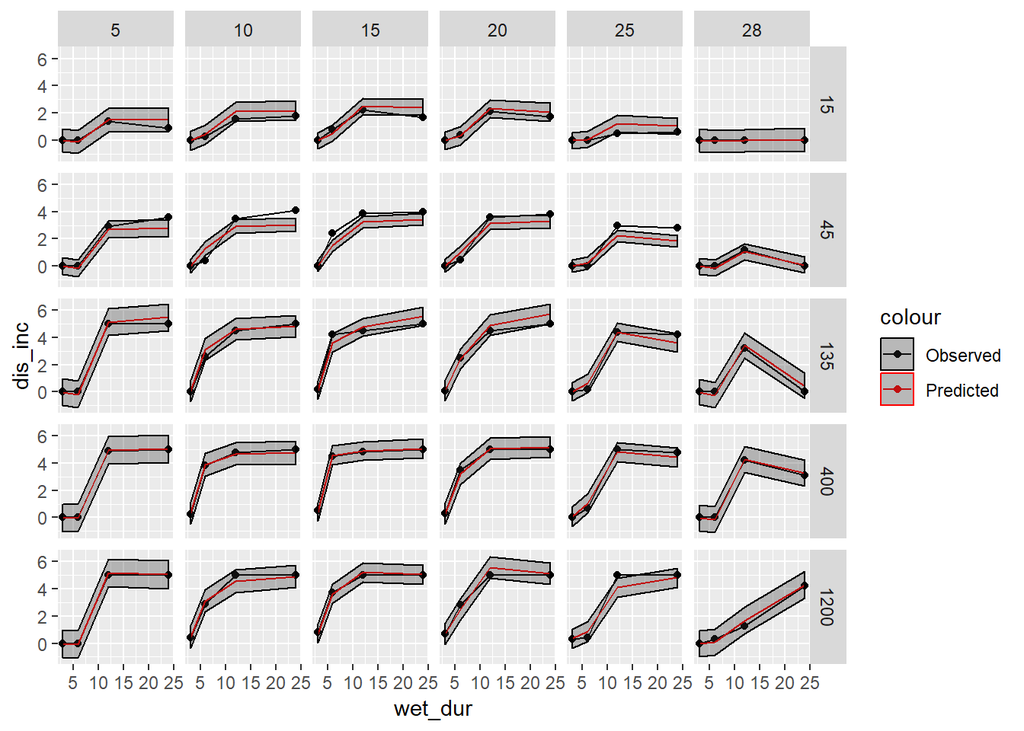

```r
ggplot(data = df_fit,aes(x= wet_dur, y = dis_inc, colour = "Observed"))+
  geom_point()+
  geom_line()+
  geom_line(aes(wet_dur, fit, colour = "Predicted")) +
  geom_ribbon(aes(ymin=lwr,ymax=upr), alpha=0.3)+
  scale_color_manual(values = c(
    Observed = "black",
    Predicted = "red"))+
  facet_grid(inoculum_dose~temp)
```

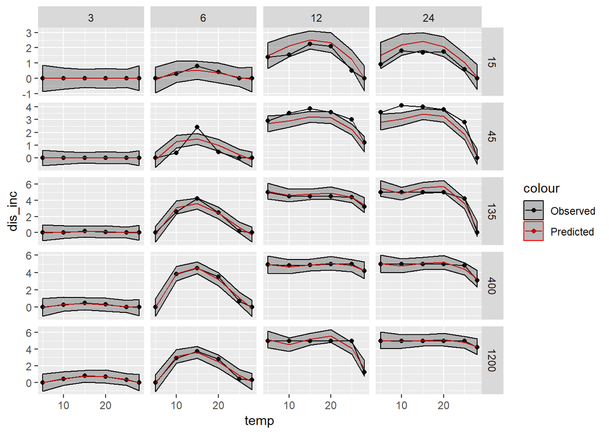

```r
ggplot(data = df_fit,aes(x= temp, y = dis_inc, colour = "Observed"))+
  geom_point()+
  geom_line()+
  geom_line(aes(temp, fit, colour = "Predicted")) +
  geom_ribbon(aes(ymin=lwr,ymax=upr), alpha=0.3)+
  scale_color_manual(values = c( Observed = "black", Predicted = "red"))+
  facet_grid(inoculum_dose~wet_dur, scales = "free")
```

Another issue is that your response is a grading scale, from 0 to 5, and therefore bounded. Hence the normal model might be innapropriate. Curiously when you do the polynomial fit the residuals look normal and assumptions seem met, even though predictions are poor. With the splines model, assumptions seem to be violated, however predictions are ok. This is something to do with the nature of the response, which is not normal, but bounded. Maybe one way of looking at this is by transforming the scale 0-5 to 0-1, and use beta regression for continuous proportions. Here is code that does that

```r
dis_df$dis_inc2 <- dis_df$dis_inc/5
dis_df$dis_inc2[dis_df$dis_inc2 == 1] <- .999
dis_df$dis_inc2[dis_df$dis_inc2 == 0] <- .001


fit <- gamlss::gamlss(dis_inc2 ~ temp * wet_dur * inoculum_dose,
                   family = BE,
                   data = dis_df)
```

```
## GAMLSS-RS iteration 1: Global Deviance = -354.7895
## GAMLSS-RS iteration 2: Global Deviance = -382.6232
## GAMLSS-RS iteration 3: Global Deviance = -386.0925
## GAMLSS-RS iteration 4: Global Deviance = -386.5556
## GAMLSS-RS iteration 5: Global Deviance = -386.6188
## GAMLSS-RS iteration 6: Global Deviance = -386.6281
## GAMLSS-RS iteration 7: Global Deviance = -386.6299
## GAMLSS-RS iteration 8: Global Deviance = -386.6302
```

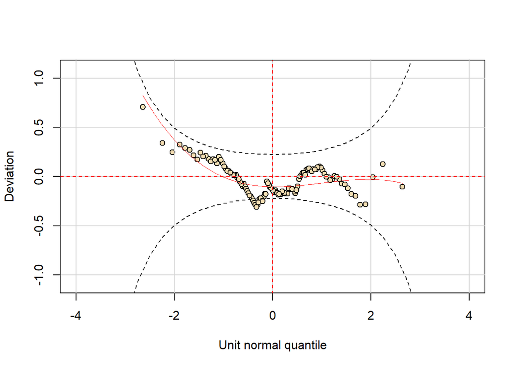

```r
wp(fit)
```

```r
wp(fit, xvar = ~ wet_dur * inoculum_dose)
```

```
## number of missing points from plot= 1  out of  12
```

```
## number of missing points from plot= 0  out of  12
```

```
## number of missing points from plot= 0  out of  12
```

```
## number of missing points from plot= 0  out of  12
```

```
## number of missing points from plot= 0  out of  12
```

```
## number of missing points from plot= 0  out of  12
```

```
## number of missing points from plot= 0  out of  12
```

```
## number of missing points from plot= 0  out of  12
```

```
## number of missing points from plot= 0  out of  12
```

```
## number of missing points from plot= 0  out of  12
```

```
## number of missing points from plot= 1  out of  12
```

```
## number of missing points from plot= 0  out of  12
```

```
## number of missing points from plot= 0  out of  12
```

```
## number of missing points from plot= 0  out of  12
```

```
## number of missing points from plot= 1  out of  12
```

```
## number of missing points from plot= 0  out of  12
```

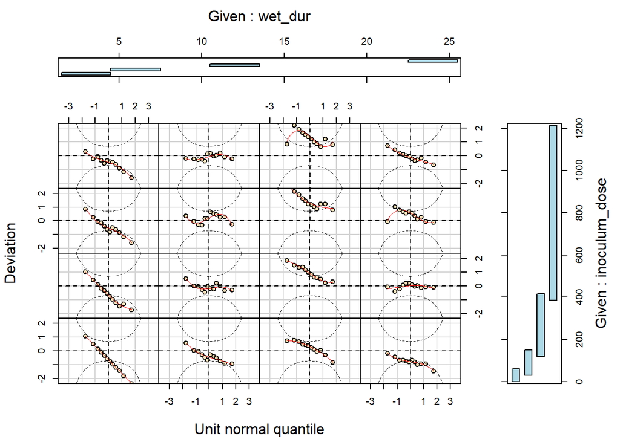

```r
df_fit <- cbind(dis_df, fit = gamlss:: predictAll(fit,newdata = dis_df, se.fit = TRUE))
```

```
## dev: -386.6302 -386.6302 0
## df: 9 9 0
```

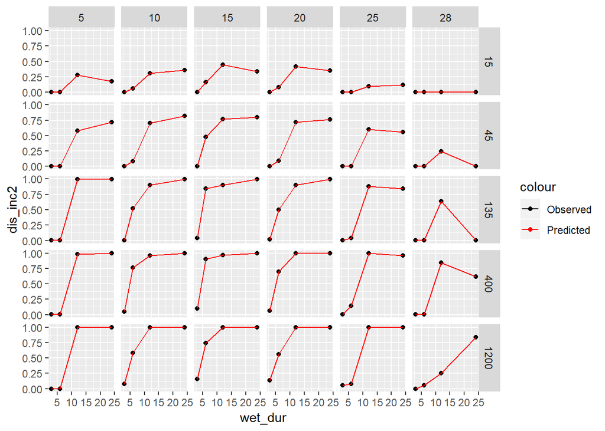

```r
ggplot(data = df_fit,aes(x= wet_dur, y = dis_inc2, colour = "Observed"))+
  geom_point()+
  geom_line()+
  geom_line(aes(wet_dur, fit.y, colour = "Predicted")) +
  # geom_ribbon(aes(ymin=lwr,ymax=upr), alpha=0.3)+
  scale_color_manual(values = c(
    Observed = "black",
    Predicted = "red"))+
  facet_grid(inoculum_dose~temp)
```

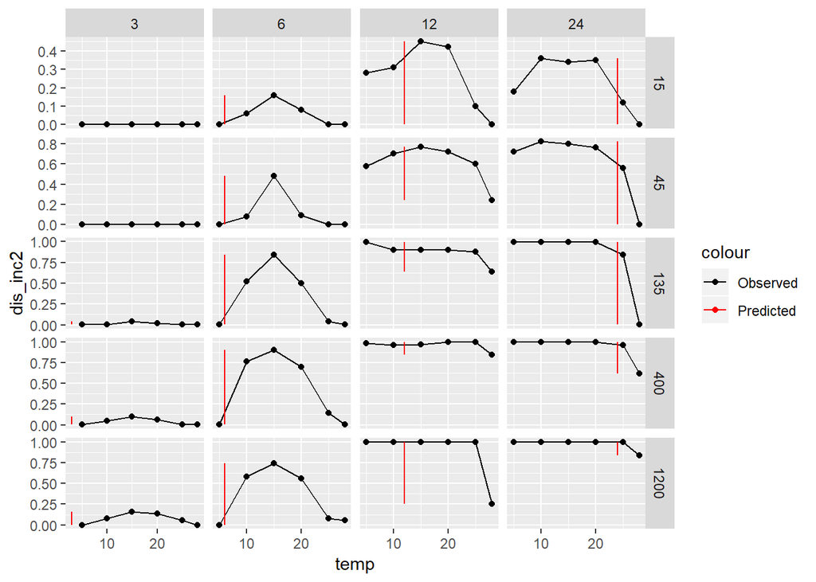

```r
ggplot(data = df_fit,aes(x= temp, y = dis_inc2, colour = "Observed"))+
  geom_point()+
  geom_line()+
  geom_line(aes(wet_dur, fit.y, colour = "Predicted")) +
  # geom_ribbon(aes(ymin=lwr,ymax=upr), alpha=0.3)+
  scale_color_manual(values = c( Observed = "black", Predicted = "red"))+
  facet_grid(inoculum_dose~wet_dur, scales = "free")
```

You can also include polynomials in there, as well as model the scale with covariates, by using

```r
fit2 <- gamlss(dis_inc2 ~ temp * wet_dur * inoculum_dose,
                   sigma.formula = ~ temp * wet_dur * inoculum_dose,
                   family = BE,
                   data = dis_df)
```

```
## GAMLSS-RS iteration 1: Global Deviance = -380.1521
## GAMLSS-RS iteration 2: Global Deviance = -407.7838
## GAMLSS-RS iteration 3: Global Deviance = -409.4478
## GAMLSS-RS iteration 4: Global Deviance = -409.8285
## GAMLSS-RS iteration 5: Global Deviance = -409.9577
## GAMLSS-RS iteration 6: Global Deviance = -410.0142
## GAMLSS-RS iteration 7: Global Deviance = -410.048
## GAMLSS-RS iteration 8: Global Deviance = -410.0708
## GAMLSS-RS iteration 9: Global Deviance = -410.087
## GAMLSS-RS iteration 10: Global Deviance = -410.0972
## GAMLSS-RS iteration 11: Global Deviance = -410.1052
## GAMLSS-RS iteration 12: Global Deviance = -410.1116
## GAMLSS-RS iteration 13: Global Deviance = -410.1168
## GAMLSS-RS iteration 14: Global Deviance = -410.1209
## GAMLSS-RS iteration 15: Global Deviance = -410.1243
## GAMLSS-RS iteration 16: Global Deviance = -410.1271
## GAMLSS-RS iteration 17: Global Deviance = -410.1293
## GAMLSS-RS iteration 18: Global Deviance = -410.1306
## GAMLSS-RS iteration 19: Global Deviance = -410.1317
## GAMLSS-RS iteration 20: Global Deviance = -410.1327
```

Am I not getting something here, this seems like it is just connecting the dots? This is clasic overfitting then?

```r
df_fit <- cbind(dis_df, fit = gamlss:: predictAll(fit2,newdata = dis_df, se.fit = TRUE))
```

```
## dev: -410.1327 -410.1327 0
## df: 16 16 0
```

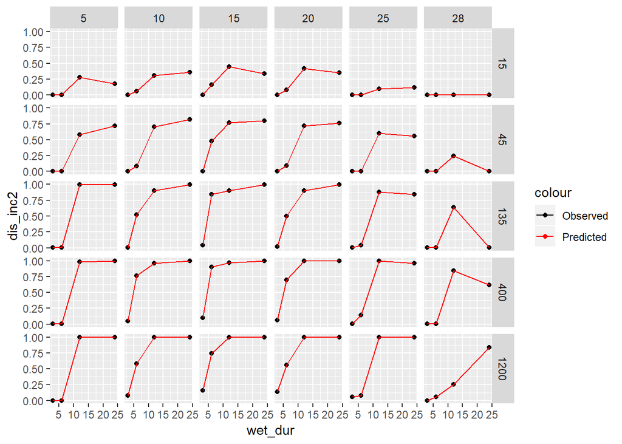

```r
ggplot(data = df_fit,aes(x= wet_dur, y = dis_inc2, colour = "Observed"))+
  geom_point()+
  geom_line()+
  geom_line(aes(wet_dur, fit.y, colour = "Predicted")) +
  # geom_ribbon(aes(ymin=lwr,ymax=upr), alpha=0.3)+
  scale_color_manual(values = c(
    Observed = "black",
    Predicted = "red"))+
  facet_grid(inoculum_dose~temp)
```

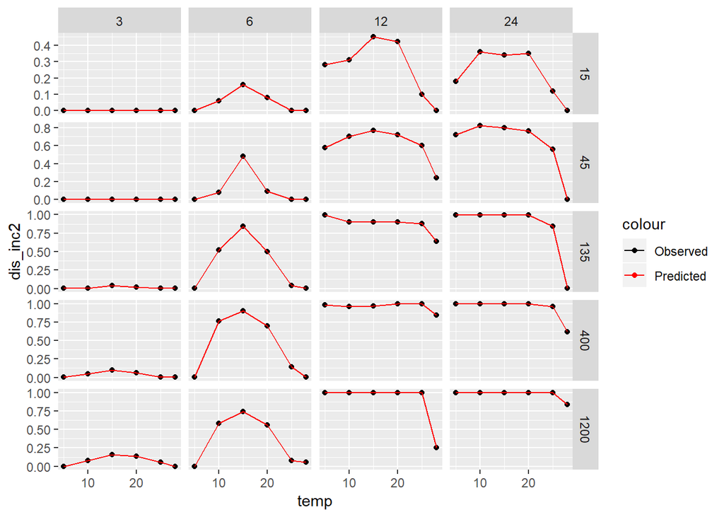

```r
ggplot(data = df_fit,aes(x= temp, y = dis_inc2, colour = "Observed"))+
  geom_point()+
  geom_line()+
  geom_line(aes(temp, fit.y, colour = "Predicted")) +
  # geom_ribbon(aes(ymin=lwr,ymax=upr), alpha=0.3)+
  scale_color_manual(values = c( Observed = "black", Predicted = "red"))+
  facet_grid(inoculum_dose~wet_dur, scales = "free")
```

### The polynomial model

```r
dis_df$inoculum_dose <- as.numeric(as.character(dis_df$inoculum_dose))

poly.fit <- lm(dis_inc ~ poly(temp,
                              wet_dur,
                              inoculum_dose,
                              degree = 3),
               data = dis_df )

summary(poly.fit)
```

```
##
## Call:
## lm(formula = dis_inc ~ poly(temp, wet_dur, inoculum_dose, degree = 3),
##     data = dis_df)
##
## Residuals:
##      Min       1Q   Median       3Q      Max
## -2.11611 -0.55673 -0.05045  0.62103  2.08640
##
## Coefficients:
##                                                      Estimate Std. Error
## (Intercept)                                           2.11417    0.07877
## poly(temp, wet_dur, inoculum_dose, degree = 3)1.0.0  -3.82113    0.86287
## poly(temp, wet_dur, inoculum_dose, degree = 3)2.0.0  -6.18862    0.86287
## poly(temp, wet_dur, inoculum_dose, degree = 3)3.0.0  -0.69107    0.86287
## poly(temp, wet_dur, inoculum_dose, degree = 3)0.1.0  13.77248    0.86287
## poly(temp, wet_dur, inoculum_dose, degree = 3)1.1.0 -26.84447    9.45231
## poly(temp, wet_dur, inoculum_dose, degree = 3)2.1.0  -5.63939    9.45231
## poly(temp, wet_dur, inoculum_dose, degree = 3)0.2.0  -8.68042    0.86287
## poly(temp, wet_dur, inoculum_dose, degree = 3)1.2.0   9.27032    9.45231
## poly(temp, wet_dur, inoculum_dose, degree = 3)0.3.0  -1.60520    0.86287
## poly(temp, wet_dur, inoculum_dose, degree = 3)0.0.1   5.87560    0.86287
## poly(temp, wet_dur, inoculum_dose, degree = 3)1.0.1   1.71190    9.45231
## poly(temp, wet_dur, inoculum_dose, degree = 3)2.0.1  -6.90072    9.45231
## poly(temp, wet_dur, inoculum_dose, degree = 3)0.1.1  33.59619    9.45231
## poly(temp, wet_dur, inoculum_dose, degree = 3)1.1.1 139.17543  103.54492
## poly(temp, wet_dur, inoculum_dose, degree = 3)0.2.1 -10.64017    9.45231
## poly(temp, wet_dur, inoculum_dose, degree = 3)0.0.2  -5.96567    0.86287
## poly(temp, wet_dur, inoculum_dose, degree = 3)1.0.2  -0.58534    9.45231
## poly(temp, wet_dur, inoculum_dose, degree = 3)0.1.2 -27.46679    9.45231
## poly(temp, wet_dur, inoculum_dose, degree = 3)0.0.3   3.77911    0.86287
##                                                     t value Pr(>|t|)
## (Intercept)                                          26.840  < 2e-16 ***
## poly(temp, wet_dur, inoculum_dose, degree = 3)1.0.0  -4.428 2.43e-05 ***
## poly(temp, wet_dur, inoculum_dose, degree = 3)2.0.0  -7.172 1.30e-10 ***
## poly(temp, wet_dur, inoculum_dose, degree = 3)3.0.0  -0.801  0.42509
## poly(temp, wet_dur, inoculum_dose, degree = 3)0.1.0  15.961  < 2e-16 ***
## poly(temp, wet_dur, inoculum_dose, degree = 3)1.1.0  -2.840  0.00547 **
## poly(temp, wet_dur, inoculum_dose, degree = 3)2.1.0  -0.597  0.55211
## poly(temp, wet_dur, inoculum_dose, degree = 3)0.2.0 -10.060  < 2e-16 ***
## poly(temp, wet_dur, inoculum_dose, degree = 3)1.2.0   0.981  0.32908
## poly(temp, wet_dur, inoculum_dose, degree = 3)0.3.0  -1.860  0.06578 .
## poly(temp, wet_dur, inoculum_dose, degree = 3)0.0.1   6.809 7.41e-10 ***
## poly(temp, wet_dur, inoculum_dose, degree = 3)1.0.1   0.181  0.85665
## poly(temp, wet_dur, inoculum_dose, degree = 3)2.0.1  -0.730  0.46706
## poly(temp, wet_dur, inoculum_dose, degree = 3)0.1.1   3.554  0.00058 ***
## poly(temp, wet_dur, inoculum_dose, degree = 3)1.1.1   1.344  0.18196
## poly(temp, wet_dur, inoculum_dose, degree = 3)0.2.1  -1.126  0.26300
## poly(temp, wet_dur, inoculum_dose, degree = 3)0.0.2  -6.914 4.51e-10 ***
## poly(temp, wet_dur, inoculum_dose, degree = 3)1.0.2  -0.062  0.95075
## poly(temp, wet_dur, inoculum_dose, degree = 3)0.1.2  -2.906  0.00451 **
## poly(temp, wet_dur, inoculum_dose, degree = 3)0.0.3   4.380 2.93e-05 ***
## ---
## Signif. codes:  0 '***' 0.001 '**' 0.01 '*' 0.05 '.' 0.1 ' ' 1
##
## Residual standard error: 0.8629 on 100 degrees of freedom
## Multiple R-squared:  0.8526, Adjusted R-squared:  0.8246
## F-statistic: 30.45 on 19 and 100 DF,  p-value: < 2.2e-16
```

```r
anova(poly.fit)
```

|  | Df | Sum Sq | Mean Sq | F value | Pr(>F) |
| --- | --- | --- | --- | --- | --- |
| poly(temp, wet_dur, inoculum_dose, degree = 3) | 19 | 430.77070 | 22.6721422 | 30.45071 | 3.471942e-33 |
| Residuals | 100 | 74.45521 | 0.7445521 | NA | NA |

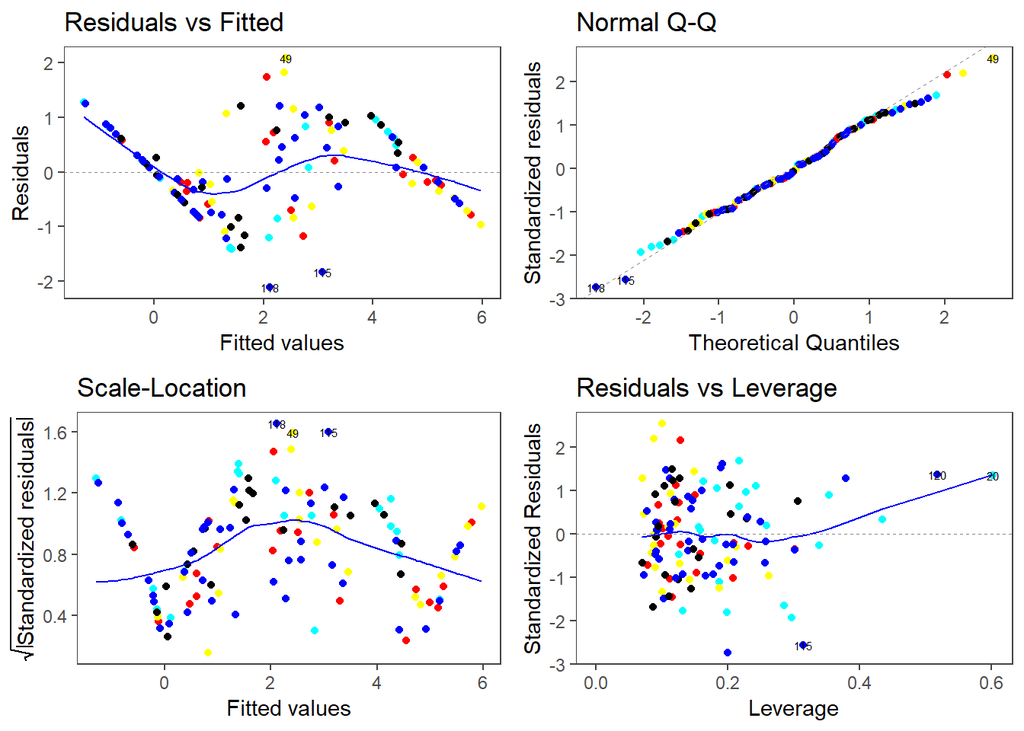

```r
library(ggfortify)
autoplot(poly.fit, label.size = 2,
         data = dis_df,
         colour = factor(dis_df$temp, ordered = T))+
  theme_article()
```

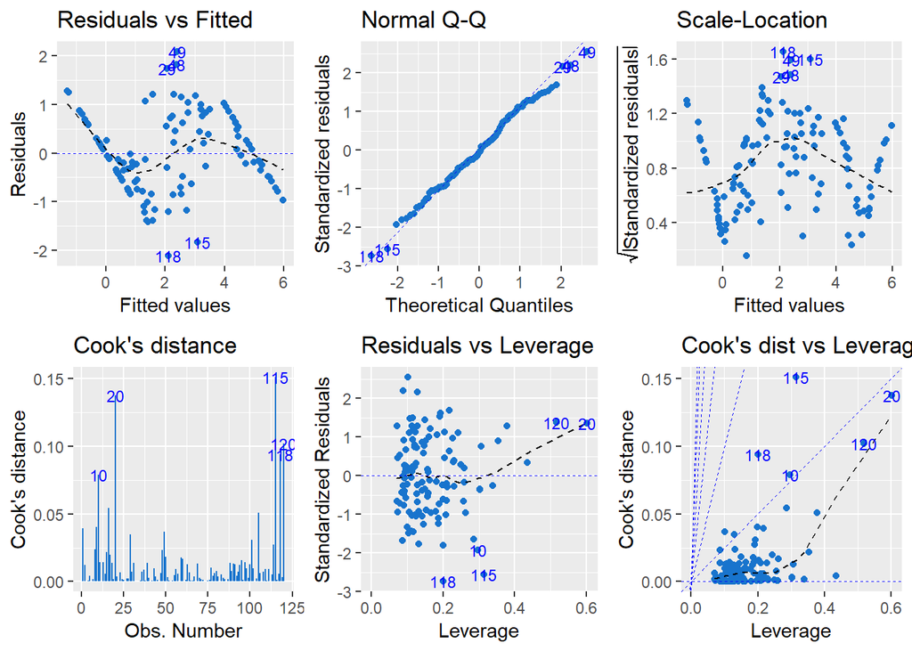

```r
autoplot(poly.fit, which = 1:6, colour = 'dodgerblue3',
         smooth.colour = 'black', smooth.linetype = 'dashed',
         ad.colour = 'blue',
         label.size = 3, label.n = 5, label.colour = 'blue',
         ncol = 3)
```

```r
#Problem scale location
```

The problem with the polynomial fit.

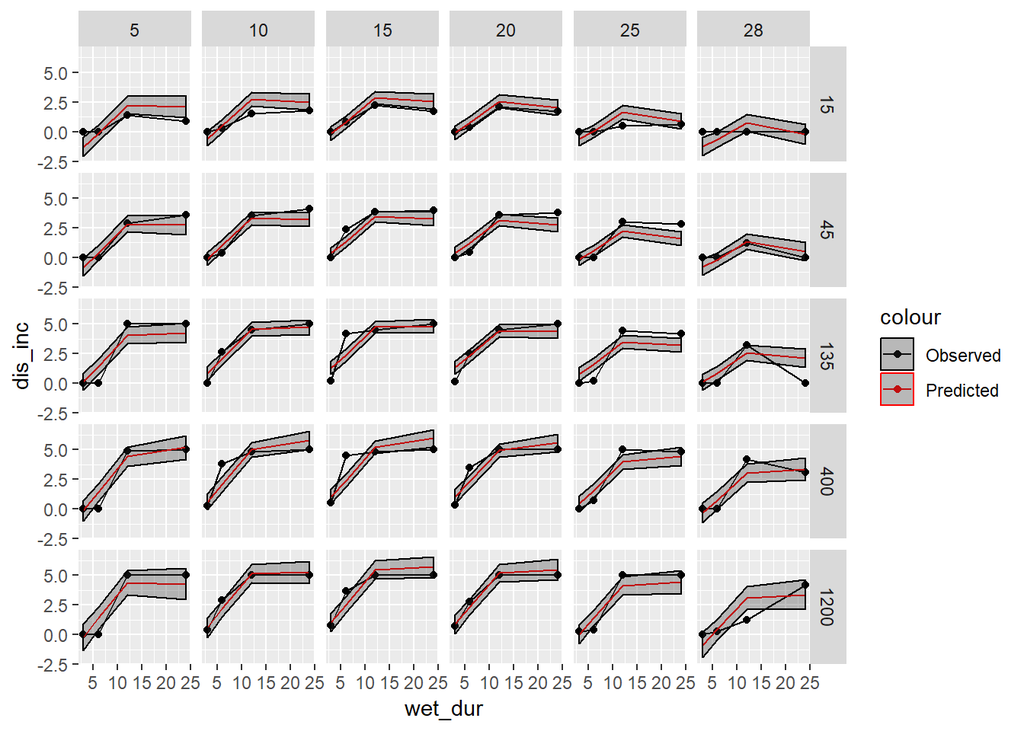

```r
dis_df$temp <- as.numeric(as.character(dis_df$temp))

df_fit <- cbind(dis_df, predict(poly.fit,dis_df, interval = 'confidence'))
dis_df <-
  reshape2::melt(dis_df, id.var = 1:2, variable.name = "temp", value.name = "dis_inc",factorsAsStrings = F)

ggplot(data = df_fit,aes(x= wet_dur, y = dis_inc, colour = "Observed"))+
  geom_point()+
  geom_line()+
  geom_line(aes(wet_dur, fit, colour = "Predicted")) +
  geom_ribbon(aes(ymin=lwr,ymax=upr), alpha=0.3)+
  scale_color_manual(values = c(
    Observed = "black",
    Predicted = "red"))+
  facet_grid(inoculum_dose~temp)
```

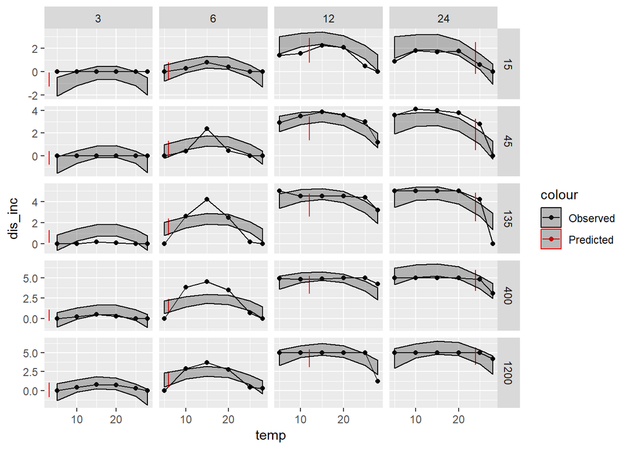

```r
ggplot(data = df_fit,aes(x= temp, y = dis_inc, colour = "Observed"))+
  geom_point()+
  geom_line()+
  geom_line(aes(wet_dur, fit, colour = "Predicted")) +
  geom_ribbon(aes(ymin=lwr,ymax=upr), alpha=0.3)+
  scale_color_manual(values = c( Observed = "black", Predicted = "red"))+
  facet_grid(inoculum_dose~wet_dur, scales = "free")
```

!The problem is that it does not follow the biological nature of the process.

# References

Rotem, J. 1971. Relativity of Limiting and Optimum Inoculum Loads, Wetting Durations, and Temperatures for Infection by Phytophthora infestans. Phytopathology. 61:275 Available at: http://www.apsnet.org/publications/phytopathology/backissues/Documents/1971Abstracts/Phyto61_275.htm [Accessed March 23, 2018].